# Analyse des données des joueurs (expérimentations finales)

# Description datas (recherche outliers)

## Ecart type de la mise

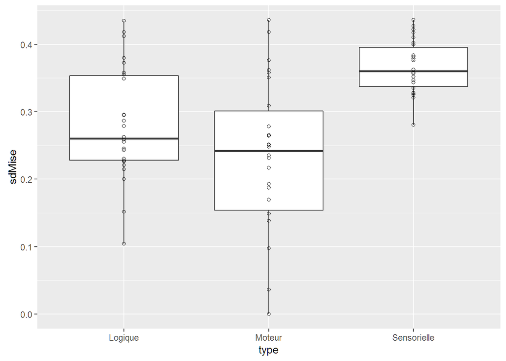

```
## [1] "Id out motrice sdMise: "
```

```
## [1] "Id out senso sdMise: "
```

```
## [1] "Id out logique sdMise: "
```

## Moyenne de la mise

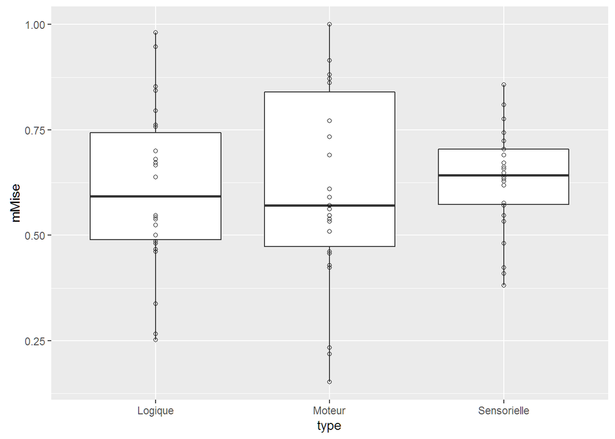

```
## [1] "Id out motrice mMise: "
```

```
## [1] "Id out senso mMise: "
```

```
## [1] "Id out logique mMise: "
```

## Somme des mises

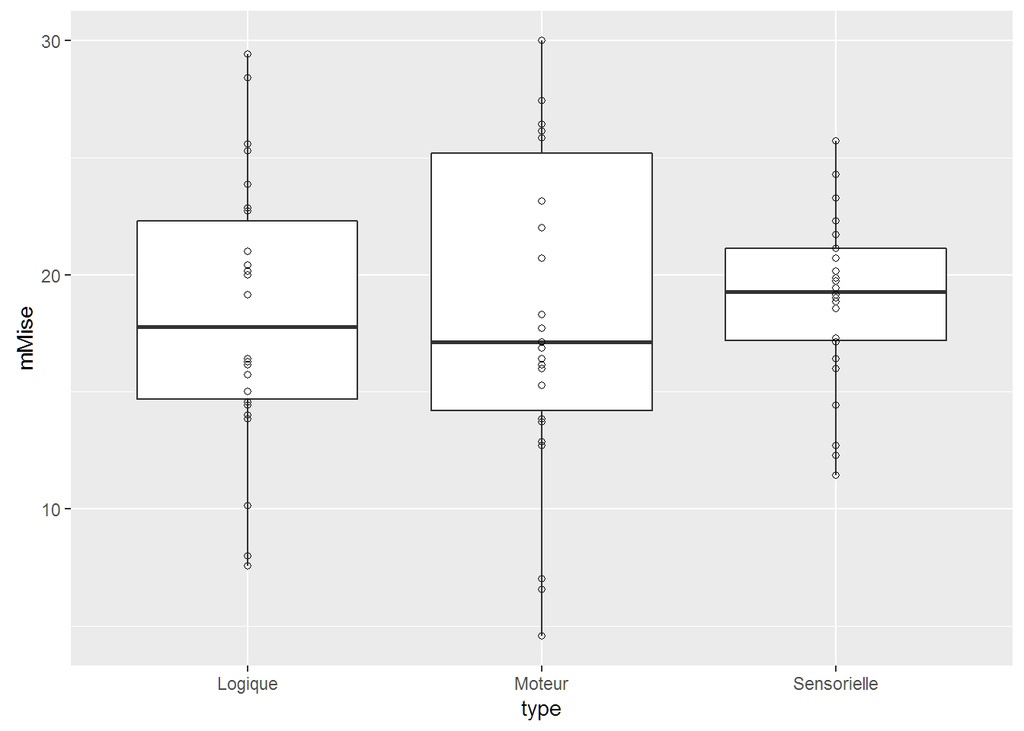

```
## [1] "Id out motrice sum Mise: "
```

```
## [1] "Id out senso sum Mise: "
```

```
## [1] "Id out logique sum Mise: "
```

## Difficulte constatée $\sum(win)$

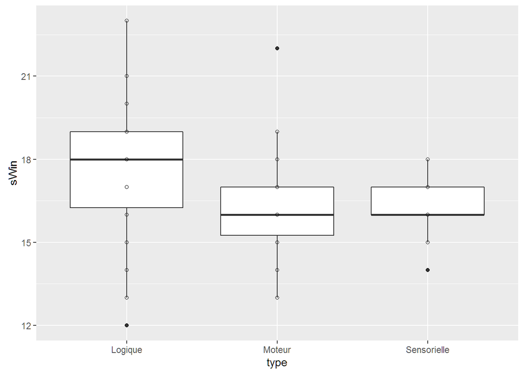

```
## [1] "Id out motrice sum win: l6ehn7zmg"
```

```
## [1] "Id out senso sum win: kilus9179, 0dnwps8w8"
```

```
## [1] "Id out logique sum win: "
```

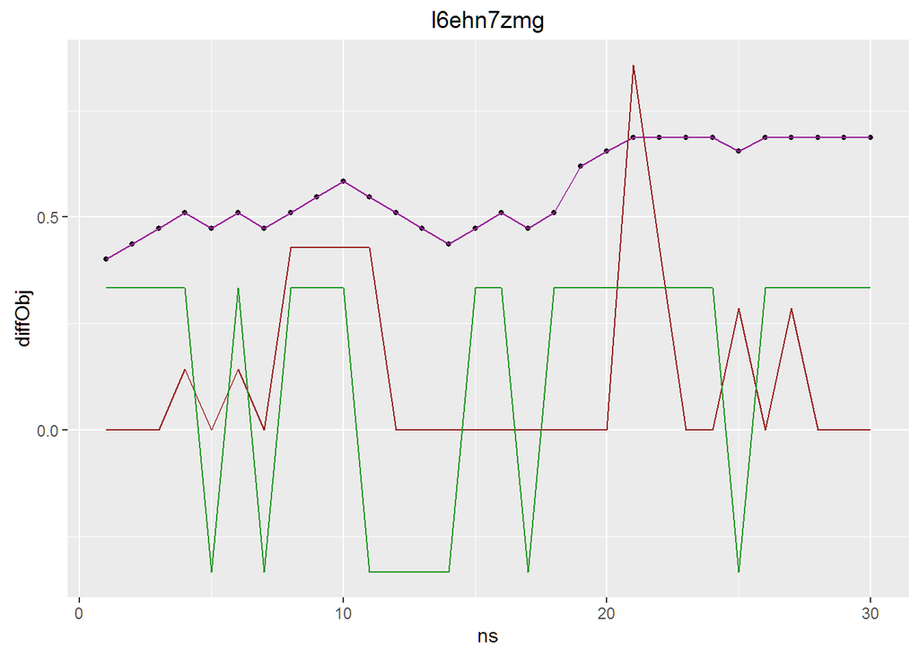

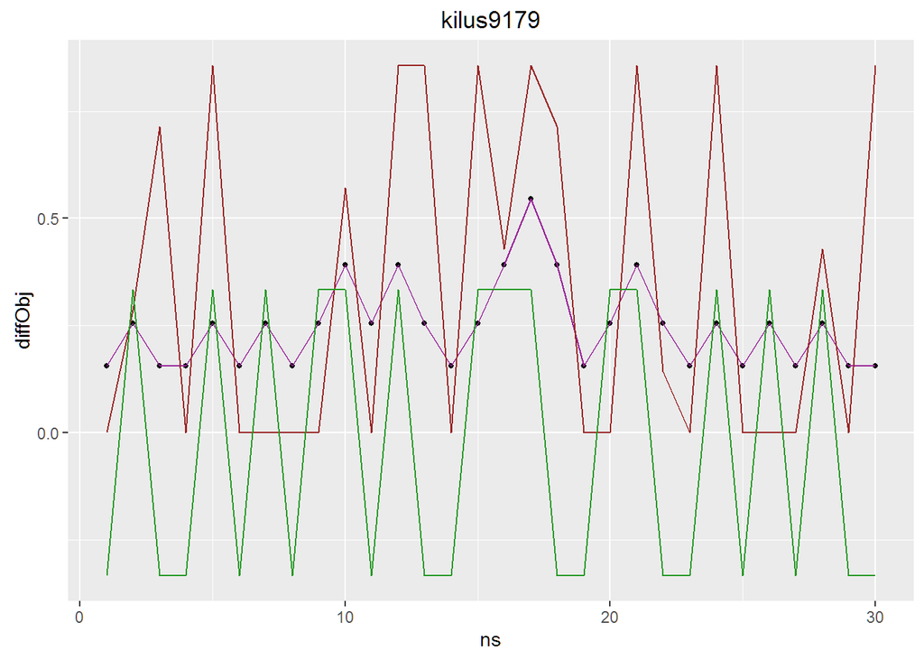

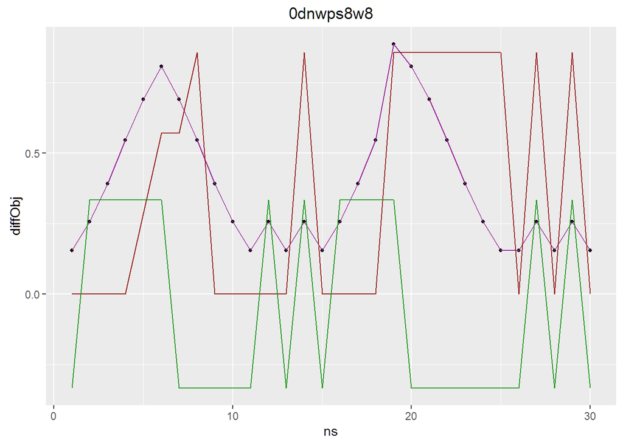

# Estimation de l’excès et du manque de confiance

Une deuxième étape consiste à vérifier si l’évolution de la difficulté du jeu a un impact sur la difficulté ressentie par les joueurs, la mise servant ici de référence. L’analyse précédente a permis de pouvoir obtenir la difficulté réelle de chaque jeu, nouvelle variable qui sert dorénavant de mesure de base pour observer les variations de la difficulté ressentie par le joueur.

Deux nouvelles mesures sont ajoutées :

- Le nombre d’échecs consécutifs du joueur (noté **nbFail**), qui permet de vérifier sa progression. Un échec faisant revenir le joueur à une tâche de difficulté moindre ; plus le joueur perd, plus la difficulté du jeu baisse.
- Le nombre de succès consécutifs du joueur (noté **nbWin**), où un succès entraîne une augmentation de la difficulté au tour suivant ; autrement dit, plus le joueur gagne, plus la difficulté augmente.

Dans les deux cas, il n’y a modification de la progression de la difficulté que si le statut de réussite du joueur change (de gagnant à perdant, de perdant à un gagnant).

La mise, basée sur une échelle de Likert de 1 à 7 points, permet d’obtenir une appréciation pour chaque tour de jeu de la difficulté ressentie par le joueur (et non de la difficulté réelle de la tâche). La mise est donc normalisée, entre 0 et 1, à laquelle on retranche la difficulté réelle calculée en amont. Cette différence nous permet d’obtenir l’erreur d’appréciation de la difficulté du jeu, cadrée ici entre -1 et +1.

Les figures suivantes présentent ainsi, pour tous les jeux puis pour chacun d’entre-eux (et donc pour chaque type de difficulté), le nombre d’échecs consécutifs (nbFail) et de succès consécutifs (nbWin) par rapport à l’erreur d’appréciation de la difficulté par le joueur. Chaque figure est accompagnée des conclusions d’une analyse de la variance (ANOVA) et de la régression linéaire, tracée en vert. La courbe rouge correspond aux valeurs médianes, les bleues mesurent quant à elles deux fois l’écart type, signifiant le faible nombre de participants. Malgré cette limite, il est possible de commenter ces données, en attendant de les confronter à celles qui vont être récupérées sur une population plus importante lors des expérimentations finales.

## Tous jeux confondus

Pour l’ensemble des données tirées des trois jeux, on observe dans le cas d’échecs consécutifs une sur-estimation de la difficulté du jeu, laissant à penser que le joueur développe un manque de confiance quant à ses chances de réussir. A l’inverse, lorsque le joueur cumule les succès, il aurait tendance à sous-estimer la difficulté du jeu, bien que l’effet soit moins visible pour les échecs. Le manque de données pour ce cas peut en être à l’origine.

### Nombre d’échecs consécutifs

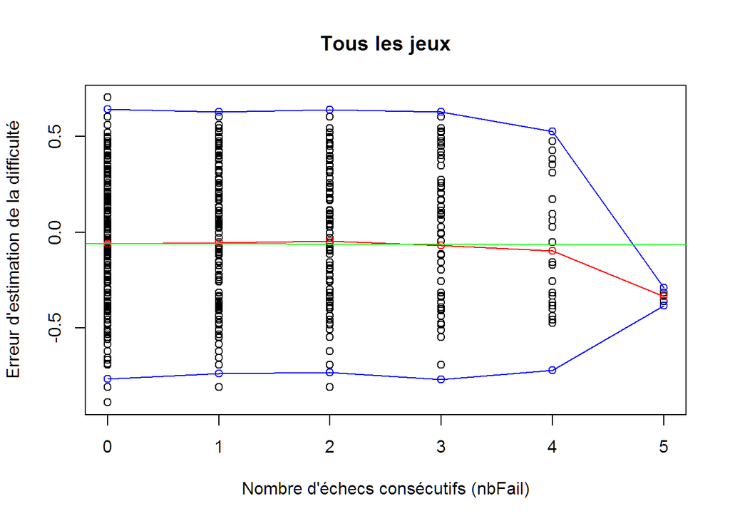

```
## [1] "Anova"
## [1] "Regression linéaire"
```

```
## [1] "pvalue anova"
```

```
## [1] "0.85 :("
```

### Nombre de réussites consécutives

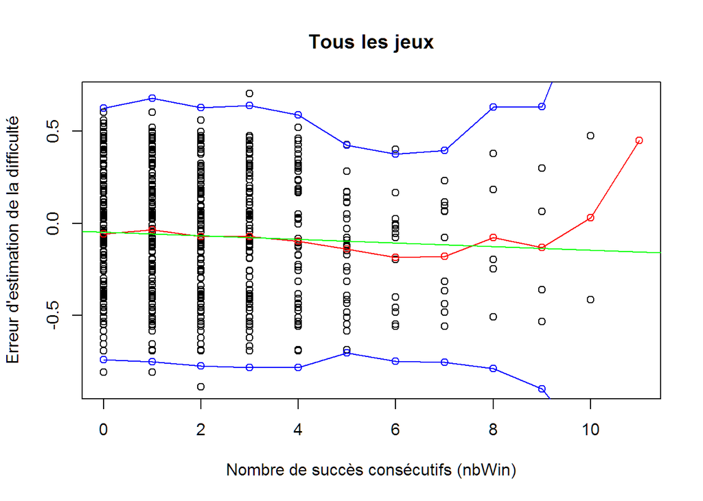

```
## [1] "Anova"
## [1] "Regression linéaire"
```

```
## [1] "pvalue anova"
```

```
## [1] "0.054 :("
```

### Indice de confiance lissé

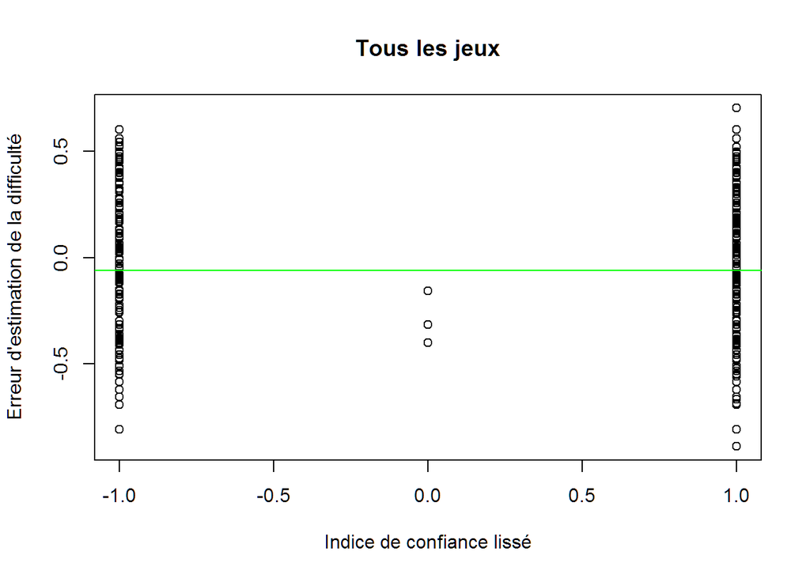

```
## [1] "Anova res lisse"
## [1] "Regression linéaire"
```

```
## [1] "pvalue anova"
```

```
## [1] "0.81 :("
```

## Difficulté logique

Indépendamment pour le jeu de déduction, le nombre d’échecs consécutifs ne semble pas avoir un trop important impact sur l’estimation de la difficulté par le joueur, et ne conduirait pas à un manque de confiance. Une hypothèse serait que, face à ce type de difficulté, le joueur aurait plus de temps pour apprécier son aptitude à résoudre le problème donné et donc une meilleure appréciation de la difficulté. A l’inverse, il ferait preuve d’un léger excès de confiance dans le cas de succès répétés. De nouvelles données permettront de mieux cerner ces comportements.

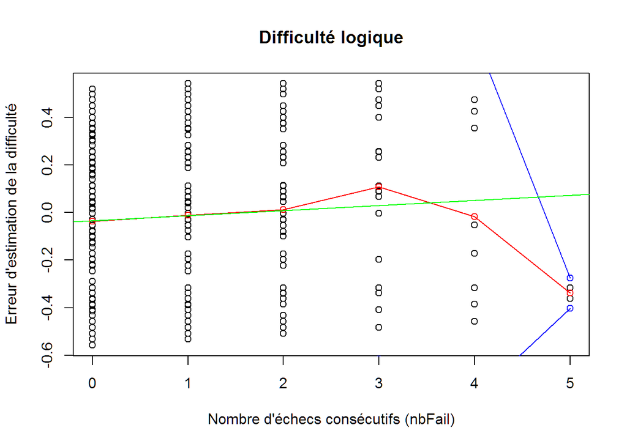

```
## [1] "Anova"
## [1] "Regression linéaire"
```

```
## [1] "pvalue anova"
```

```
## [1] "0.12 :("
```

```
## [1] "plotLinModels == FALSE"
```

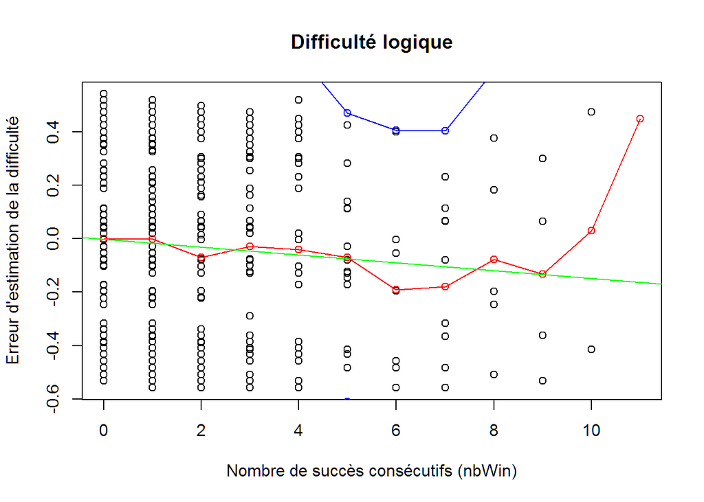

```
## [1] "Anova"
## [1] "Regression linéaire"
```

```
## [1] "pvalue anova"
```

```
## [1] "0.037 *"
```

```
## [1] "plotLinModels == FALSE"
```

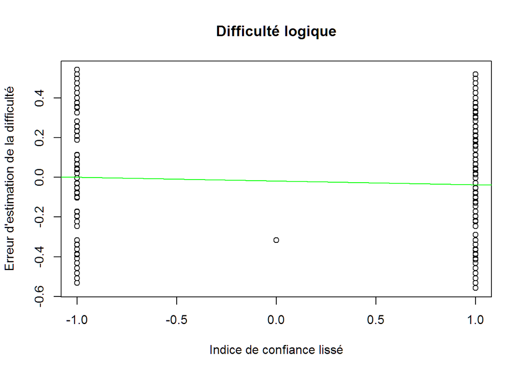

```
## [1] "Anova res lisse"
## [1] "Regression linéaire"
```

```
## [1] "pvalue anova"
```

```
## [1] "0.14 :("
```

```
## [1] "plotLinModels == FALSE"
```

### Courbes de difficulte

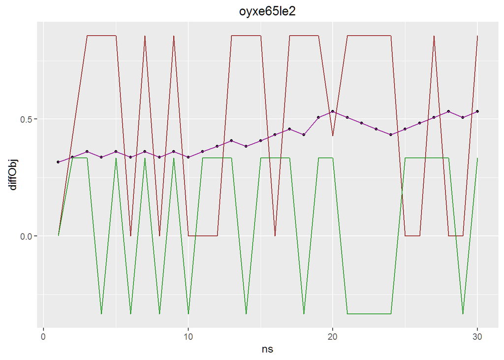

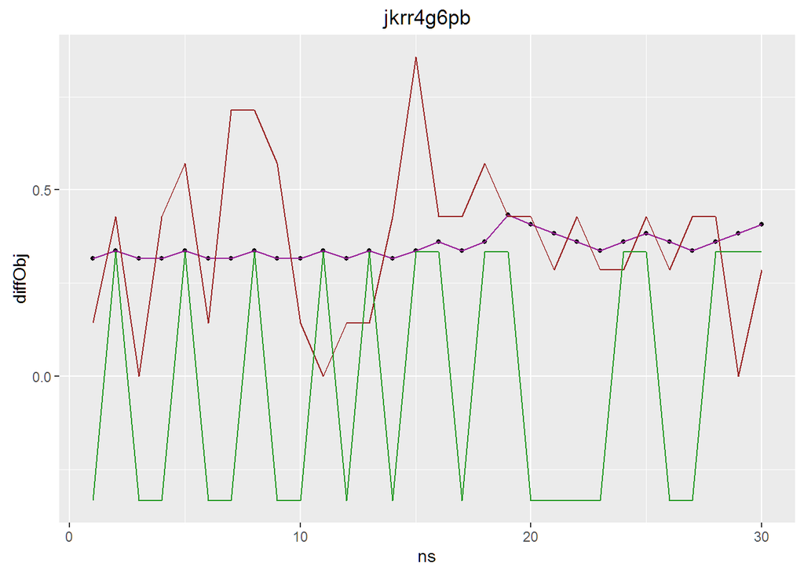

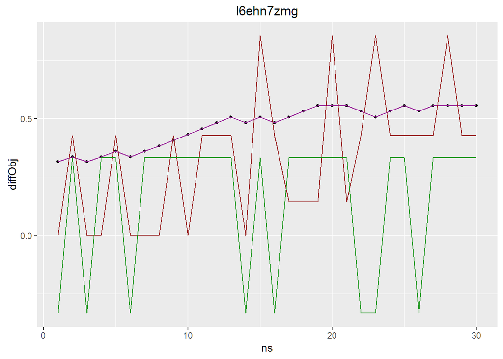

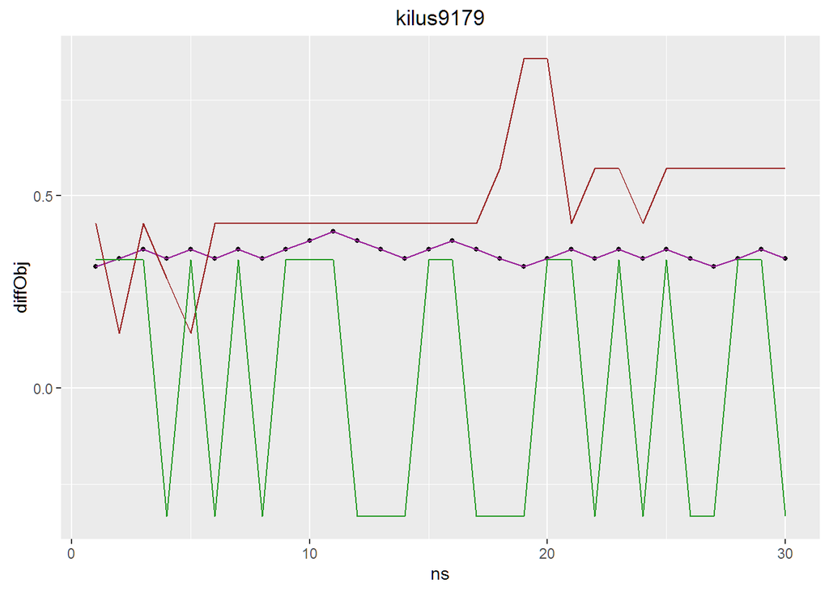

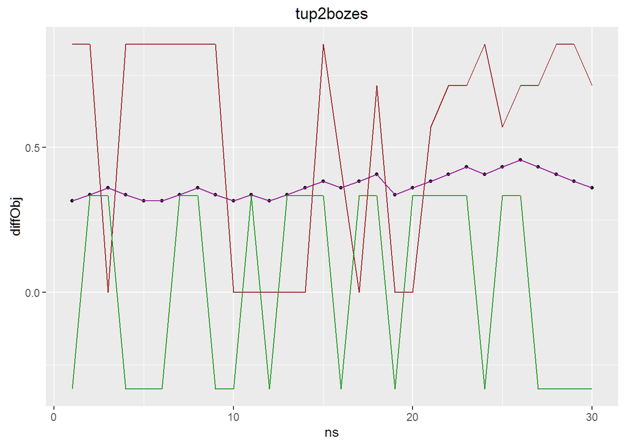

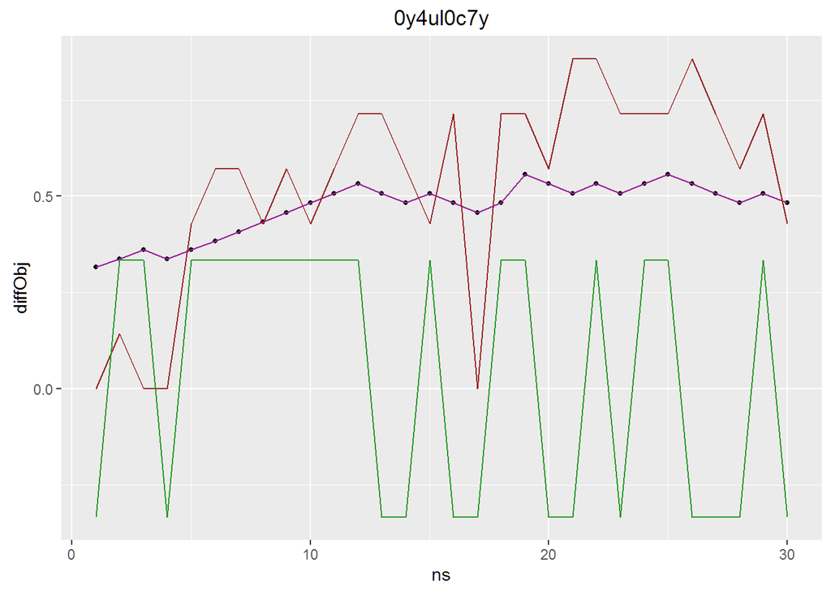

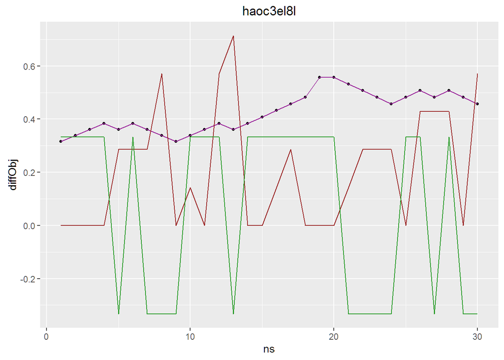

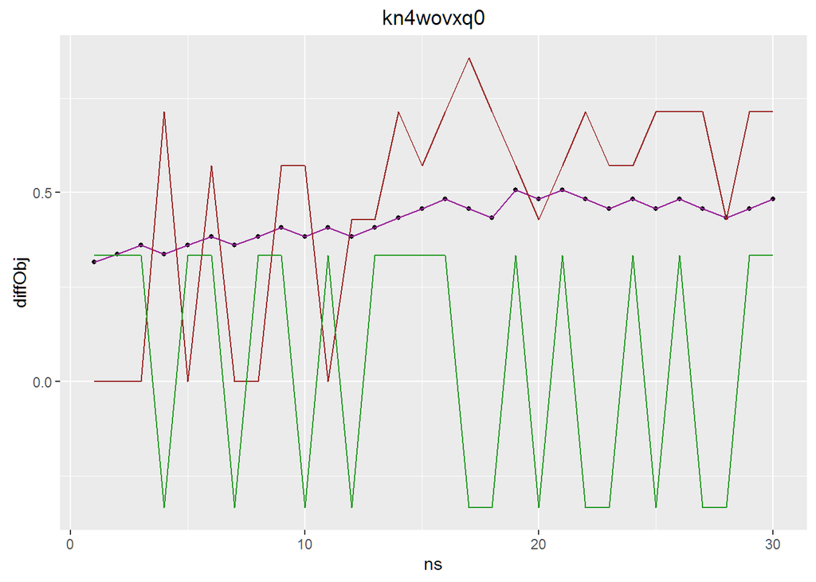

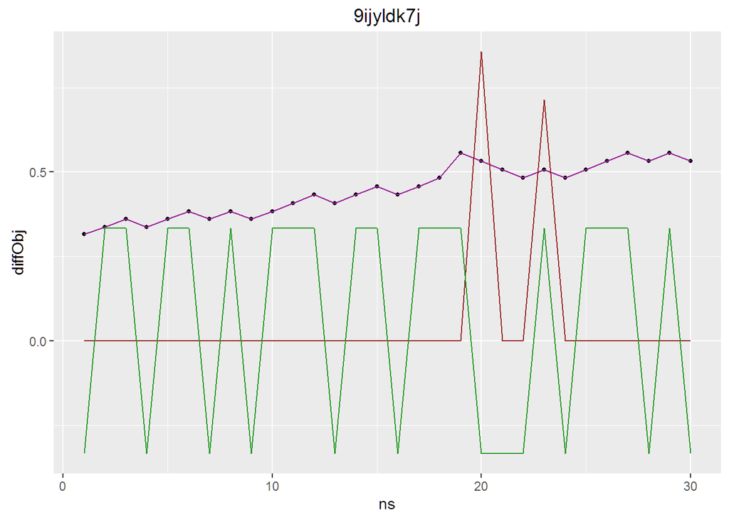

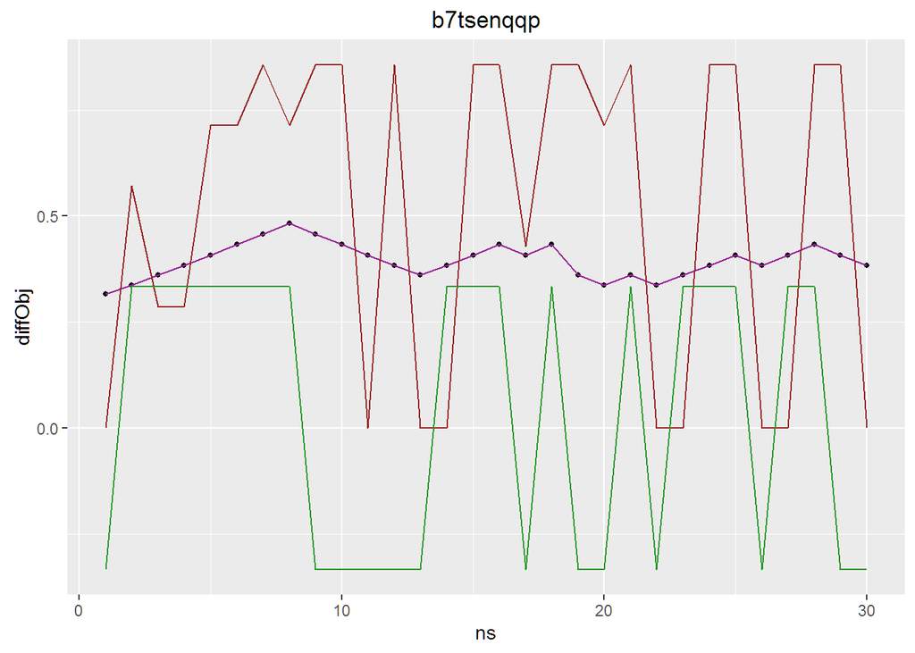

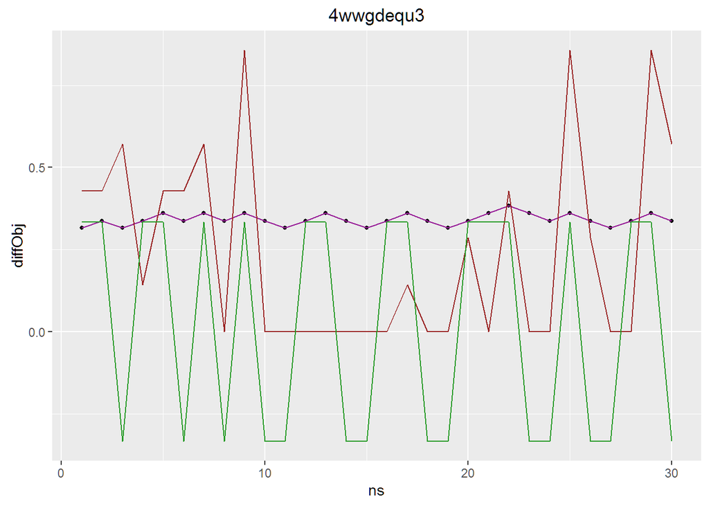

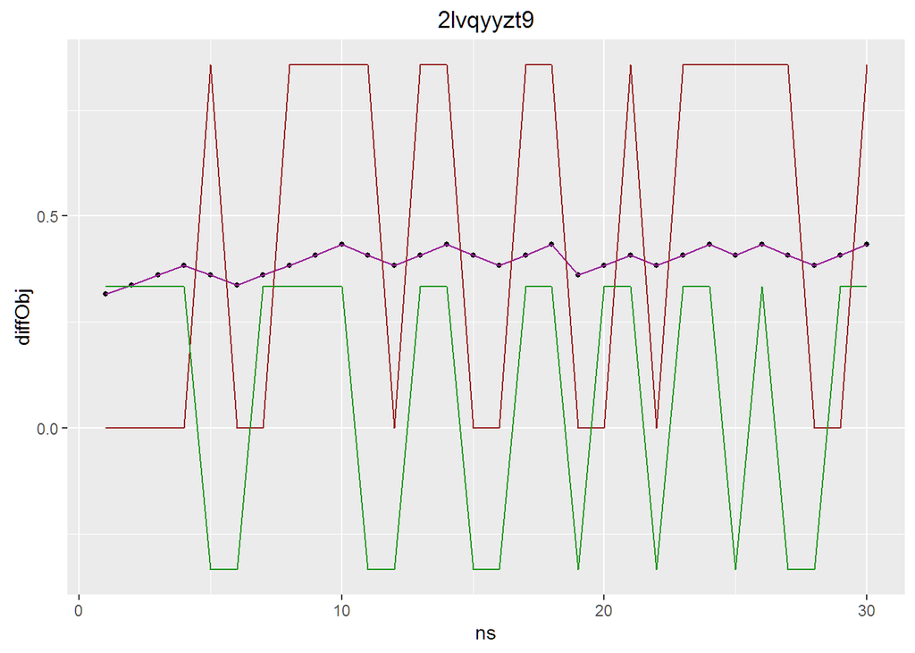

[14 more figures not shown]

## Difficulté motrice

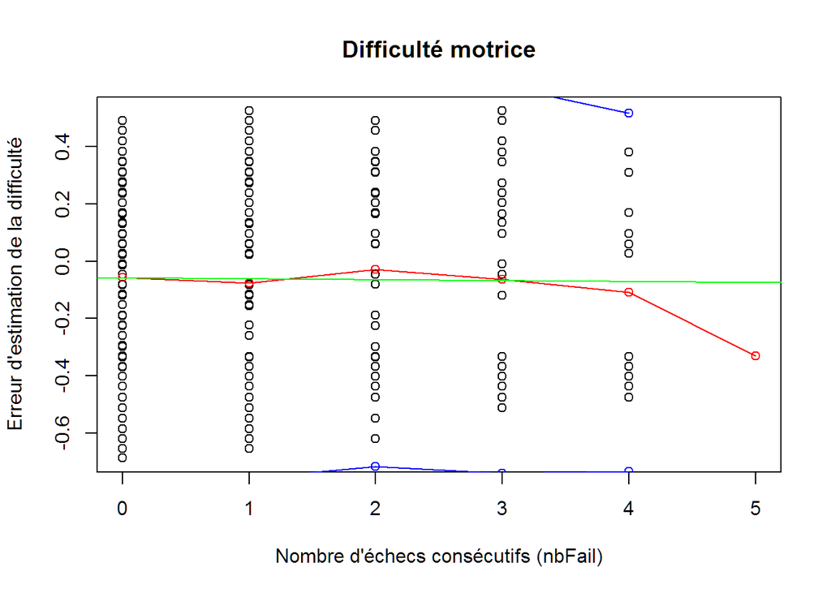

```
## [1] "Anova"
## [1] "Regression linéaire"
```

```
## [1] "pvalue anova"
```

```
## [1] "0.81 :("
```

```
## [1] "plotLinModels == FALSE"
```

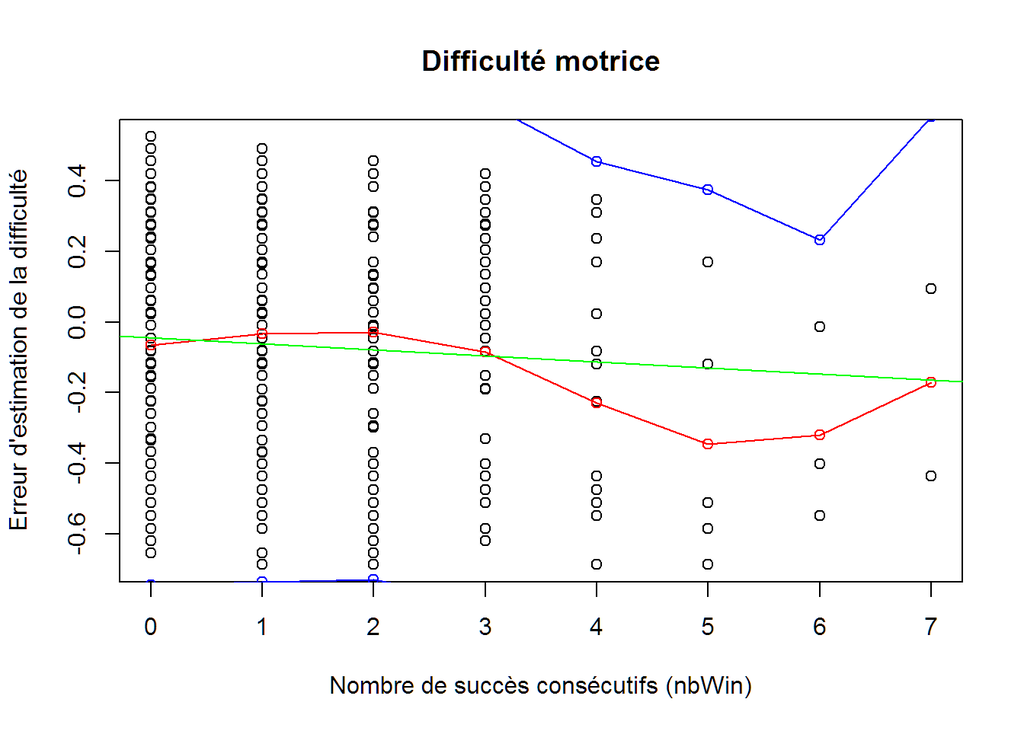

```
## [1] "Anova"
## [1] "Regression linéaire"
```

```
## [1] "pvalue anova"
```

```
## [1] "0.11 :("
```

```
## [1] "plotLinModels == FALSE"
```

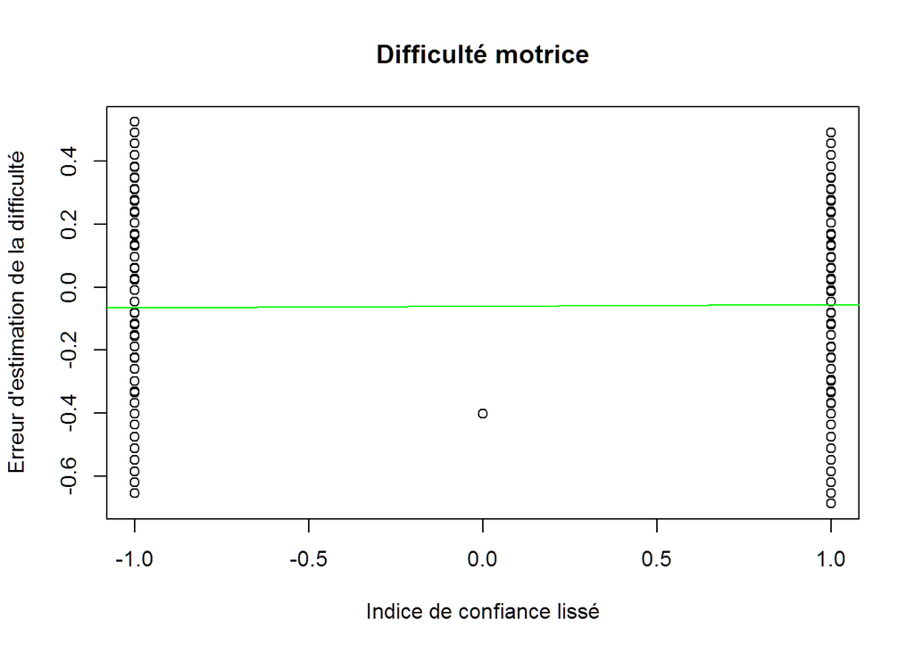

```
## [1] "Anova res lisse"
## [1] "Regression linéaire"
```

```
## [1] "pvalue anova"
```

```
## [1] "0.69 :("
```

```
## [1] "plotLinModels == FALSE"
```